# Introduction to Tidyverse: Transforming Data (dplyr)

Siegfred Codia

We initialize the package and the data needed. In this part, `dplyr` is the package that we need, which is again already included with the `tidyverse` package.

```r
library(tidyverse)
satisfaction <- read_rds("satisfaction.rds")
```

## Filter Rows

We can use to filter() to filter rows based on several conditions.

```r
filter(.data = satisfaction, sex == "Male", age > 40)
```

| emp_id | age | birthdate | sex | daily_rate | department | work_tenure | work_life | relationship | job_role |
| --- | --- | --- | --- | --- | --- | --- | --- | --- | --- |
| emp3682 | 50 | 1971-10-20 | Male | 600 | Research & Development | 0 | Dissatisfied | Neutral | Neutral |
| emp2855 | 42 | 1979-10-18 | Male | 500 | Sales | 3 | Neutral | Satisfied | Very Dissatisfied |
| emp3938 | 41 | 1980-10-17 | Male | 700 | Research & Development | 2 | Dissatisfied | Very Dissatisfied | Satisfied |
| emp2927 | 43 | 1978-10-18 | Male | 1500 | Research & Development | 0 | Neutral | Neutral | Dissatisfied |
| emp1492 | 55 | 1966-10-21 | Male | 700 | Sales | 9 | Neutral | Neutral | Dissatisfied |
| emp2589 | 52 | 1969-10-20 | Male | 1500 | Research & Development | 12 | Dissatisfied | Dissatisfied | Neutral |
| emp3763 | 41 | 1980-10-17 | Male | 700 | Research & Development | 2 | Neutral | Dissatisfied | Dissatisfied |
| emp804 | 42 | 1979-10-18 | Male | 1400 | Sales | 2 | Neutral | Neutral | Very Dissatisfied |
| emp4493 | 44 | 1977-10-18 | Male | 1400 | Sales | 1 | Very Dissatisfied | Very Dissatisfied | Neutral |
| emp31 | 42 | 1979-10-18 | Male | 1400 | Research & Development | 5 | Dissatisfied | Satisfied | Satisfied |

[output cut: 470 more lines]

Conditions must all be true to be selected. You must use | to explicitly use an OR conjunction.

```r
filter(.data = satisfaction, work_life == "Very Dissatisfied" | relationship == "Very Dissatisfied")
```

| emp_id | age | birthdate | sex | daily_rate | department | work_tenure | work_life | relationship | job_role |
| --- | --- | --- | --- | --- | --- | --- | --- | --- | --- |
| emp2884 | 40 | 1981-10-17 | Female | 900 | Sales | 2 | Neutral | Very Dissatisfied | Satisfied |
| emp540 | 24 | 1997-10-13 | Male | 400 | Research & Development | 1 | Neutral | Very Dissatisfied | Neutral |
| emp811 | 38 | 1983-10-17 | Male | 1300 | Research & Development | 10 | Neutral | Very Dissatisfied | Very Dissatisfied |
| emp1010 | 32 | 1989-10-15 | Male | 900 | Sales | 4 | Neutral | Very Dissatisfied | Satisfied |
| emp3938 | 41 | 1980-10-17 | Male | 700 | Research & Development | 2 | Dissatisfied | Very Dissatisfied | Satisfied |
| emp4055 | 37 | 1984-10-16 | Male | 1400 | Research & Development | 3 | Satisfied | Very Dissatisfied | Dissatisfied |
| emp5021 | 35 | 1986-10-16 | Male | 600 | Sales | 0 | Very Dissatisfied | Very Dissatisfied | Neutral |
| emp5277 | 29 | 1992-10-14 | Male | 600 | Research & Development | 5 | Satisfied | Very Dissatisfied | Very Dissatisfied |
| emp4449 | 33 | 1988-10-15 | Female | 600 | Sales | 1 | Dissatisfied | Very Dissatisfied | Neutral |
| emp3186 | 38 | 1983-10-17 | Male | 1600 | Research & Development | 2 | Dissatisfied | Very Dissatisfied | Neutral |

[output cut: 630 more lines]

*Note: Recall that the* `filter` *function of* `dplyr`*have a conflict with the* `filter` *function of* `stats` *package. R might get confused sometimes which filter function you are referring to. You can force using the* `filter` *from* `dplyr` *instead from* `stats` *by using* `dplyr::filter()`.

## Select Columns

We can use `select()` function to select columns. The order of column names in the function dictates the order of columns in the output.

```r
select(.data = satisfaction, emp_id, age, birthdate, sex)
```

| emp_id | age | birthdate | sex |
| --- | --- | --- | --- |
| emp1417 | 36 | 1985-10-16 | Male |
| emp2884 | 40 | 1981-10-17 | Female |
| emp540 | 24 | 1997-10-13 | Male |
| emp2850 | 32 | 1989-10-15 | Male |
| emp3520 | 30 | 1991-10-15 | Female |
| emp3682 | 50 | 1971-10-20 | Male |
| emp2855 | 42 | 1979-10-18 | Male |
| emp811 | 38 | 1983-10-17 | Male |
| emp2723 | 40 | 1981-10-17 | Male |
| emp3662 | 38 | 1983-10-17 | Male |

[output cut: 2490 more lines]

There are also several help functions for selecting columns. For example, we can use a colon `:` to select a sequence of consecutive columns.

```r
select(.data = satisfaction, emp_id:sex)
```

| emp_id | age | birthdate | sex |
| --- | --- | --- | --- |
| emp1417 | 36 | 1985-10-16 | Male |
| emp2884 | 40 | 1981-10-17 | Female |
| emp540 | 24 | 1997-10-13 | Male |
| emp2850 | 32 | 1989-10-15 | Male |
| emp3520 | 30 | 1991-10-15 | Female |
| emp3682 | 50 | 1971-10-20 | Male |
| emp2855 | 42 | 1979-10-18 | Male |
| emp811 | 38 | 1983-10-17 | Male |
| emp2723 | 40 | 1981-10-17 | Male |
| emp3662 | 38 | 1983-10-17 | Male |

[output cut: 2490 more lines]

We also have name-based selection like “starts_with”, “ends_with”, and “contain”. The example below demonstrates “starts_with”

```r
select(.data = satisfaction, starts_with("work"))
```

| work_tenure | work_life |
| --- | --- |
| 1 | Dissatisfied |
| 2 | Neutral |
| 1 | Neutral |
| 6 | Neutral |
| 1 | Satisfied |
| 0 | Dissatisfied |
| 3 | Neutral |
| 10 | Neutral |
| 12 | Neutral |
| 6 | Neutral |

[output cut: 2490 more lines]

## Sort / Arrange Observations

```r
arrange(.data = satisfaction, desc(daily_rate), age)
```

| emp_id | age | birthdate | sex | daily_rate | department | work_tenure | work_life | relationship | job_role |
| --- | --- | --- | --- | --- | --- | --- | --- | --- | --- |
| emp2009 | 24 | 1997-10-13 | Male | 1600 | Sales | 1 | Neutral | Neutral | Very Dissatisfied |
| emp3346 | 24 | 1997-10-13 | Female | 1600 | Sales | 1 | Neutral | Dissatisfied | Very Dissatisfied |
| emp4391 | 27 | 1994-10-14 | Female | 1600 | Research & Development | 1 | Very Dissatisfied | Very Dissatisfied | Very Dissatisfied |
| emp3287 | 27 | 1994-10-14 | Male | 1600 | Research & Development | 1 | Neutral | Satisfied | Neutral |
| emp4429 | 27 | 1994-10-14 | Female | 1600 | Research & Development | 1 | Dissatisfied | Dissatisfied | Very Dissatisfied |
| emp4704 | 28 | 1993-10-14 | Female | 1600 | Research & Development | 2 | Neutral | Satisfied | Very Dissatisfied |
| emp1725 | 28 | 1993-10-14 | Female | 1600 | Sales | 0 | Neutral | Dissatisfied | Dissatisfied |
| emp1047 | 29 | 1992-10-14 | Male | 1600 | Research & Development | 2 | Neutral | Very Dissatisfied | Neutral |
| emp3023 | 29 | 1992-10-14 | Male | 1600 | Research & Development | 2 | Dissatisfied | Neutral | Satisfied |
| emp91 | 29 | 1992-10-14 | Male | 1600 | Sales | 5 | Neutral | Satisfied | Neutral |

[output cut: 2490 more lines]

When sorting, being an unordered or ordered factor matters. character variables are sorted alphabetically, while factor variables are sorted according to the arrangement of the levels.

Here, `emp_id` is a character variable.

```r
arrange(.data = satisfaction, emp_id)
```

| emp_id | age | birthdate | sex | daily_rate | department | work_tenure | work_life | relationship | job_role |
| --- | --- | --- | --- | --- | --- | --- | --- | --- | --- |
| emp1000 | 37 | 1984-10-16 | Male | 400 | Sales | 8 | Neutral | Very Dissatisfied | Neutral |
| emp1004 | 31 | 1990-10-15 | Female | 900 | Research & Development | 1 | Neutral | Satisfied | Neutral |
| emp1005 | 40 | 1981-10-17 | Female | 1400 | Research & Development | 4 | Neutral | Satisfied | Satisfied |
| emp1008 | 41 | 1980-10-17 | Male | 1100 | Research & Development | 1 | Neutral | Dissatisfied | Neutral |
| emp1009 | 29 | 1992-10-14 | Male | 700 | Research & Development | 1 | Neutral | Satisfied | Satisfied |
| emp101 | 41 | 1980-10-17 | Male | 1500 | Sales | 5 | Neutral | Neutral | Satisfied |
| emp1010 | 32 | 1989-10-15 | Male | 900 | Sales | 4 | Neutral | Very Dissatisfied | Satisfied |
| emp1011 | 54 | 1967-10-21 | Male | 400 | Research & Development | 0 | Neutral | Neutral | Satisfied |
| emp1012 | 44 | 1977-10-18 | Female | 400 | Research & Development | 4 | Neutral | Very Dissatisfied | Dissatisfied |
| emp1013 | 59 | 1962-10-22 | Male | 1100 | Research & Development | 10 | Neutral | Very Dissatisfied | Satisfied |

[output cut: 2490 more lines]

Here, `work_life` is an ordered factor. Notice that the arrangement of values is not alphabetical.

```r
arrange(.data = satisfaction, work_life)
```

| emp_id | age | birthdate | sex | daily_rate | department | work_tenure | work_life | relationship | job_role |
| --- | --- | --- | --- | --- | --- | --- | --- | --- | --- |
| emp5021 | 35 | 1986-10-16 | Male | 600 | Sales | 0 | Very Dissatisfied | Very Dissatisfied | Neutral |
| emp4493 | 44 | 1977-10-18 | Male | 1400 | Sales | 1 | Very Dissatisfied | Very Dissatisfied | Neutral |
| emp208 | 37 | 1984-10-16 | Male | 1300 | Research & Development | 10 | Very Dissatisfied | Very Dissatisfied | Very Dissatisfied |
| emp3001 | 35 | 1986-10-16 | Male | 400 | Research & Development | 12 | Very Dissatisfied | Neutral | Satisfied |
| emp3535 | 49 | 1972-10-19 | Male | 500 | Research & Development | 5 | Very Dissatisfied | Dissatisfied | Satisfied |
| emp2337 | 55 | 1966-10-21 | Female | 600 | Research & Development | 10 | Very Dissatisfied | Neutral | Neutral |
| emp4928 | 24 | 1997-10-13 | Male | 400 | Research & Development | 0 | Very Dissatisfied | Very Dissatisfied | Neutral |
| emp174 | 35 | 1986-10-16 | Female | 1200 | Sales | 1 | Very Dissatisfied | Neutral | Very Dissatisfied |
| emp3406 | 36 | 1985-10-16 | Female | 1200 | Research & Development | 1 | Very Dissatisfied | Neutral | Neutral |
| emp5002 | 34 | 1987-10-16 | Female | 1200 | Research & Development | 2 | Very Dissatisfied | Satisfied | Satisfied |

[output cut: 2490 more lines]

## Add / Compute New Variables

You can compute a new variable and add that new variable at the end of the data set using the mutate() function.

For example, let’s compute a new variable `happy_rel` (if relationship is Satisfied or Very Satisfied then happy_rel = 1 else happy_rel = 0) and create `work_life_code` a numeric counterpart for work_life (1 - Very Dissatisfied, 2 - Dissatisfied, 3 - Neutral, 4 - Satisfied, 5 - Very Satisfied).

```r
mutate(satisfaction,
       happy_rel = if_else(relationship == "Very Satisfied" | relationship == "Satisfied", 1, 0),
       work_life_code = case_when(work_life == "Very Dissatisfied" ~ 1,
                                  work_life == "Dissatisfied"      ~ 2,
                                  work_life == "Neutral"           ~ 3,
                                  work_life == "Satisfied"         ~ 4,
                                  work_life == "Very Satisfied"    ~ 5)
       )
```

| emp_id | age | birthdate | sex | daily_rate | department | work_tenure | work_life | relationship | job_role | happy_rel | work_life_code |
| --- | --- | --- | --- | --- | --- | --- | --- | --- | --- | --- | --- |
| emp1417 | 36 | 1985-10-16 | Male | 600 | Research & Development | 1 | Dissatisfied | Dissatisfied | Satisfied | 0 | 2 |
| emp2884 | 40 | 1981-10-17 | Female | 900 | Sales | 2 | Neutral | Very Dissatisfied | Satisfied | 0 | 3 |
| emp540 | 24 | 1997-10-13 | Male | 400 | Research & Development | 1 | Neutral | Very Dissatisfied | Neutral | 0 | 3 |
| emp2850 | 32 | 1989-10-15 | Male | 400 | Research & Development | 6 | Neutral | Neutral | Dissatisfied | 0 | 3 |
| emp3520 | 30 | 1991-10-15 | Female | 400 | Research & Development | 1 | Satisfied | Neutral | Dissatisfied | 0 | 4 |
| emp3682 | 50 | 1971-10-20 | Male | 600 | Research & Development | 0 | Dissatisfied | Neutral | Neutral | 0 | 2 |
| emp2855 | 42 | 1979-10-18 | Male | 500 | Sales | 3 | Neutral | Satisfied | Very Dissatisfied | 1 | 3 |
| emp811 | 38 | 1983-10-17 | Male | 1300 | Research & Development | 10 | Neutral | Very Dissatisfied | Very Dissatisfied | 0 | 3 |
| emp2723 | 40 | 1981-10-17 | Male | 1500 | Sales | 12 | Neutral | Satisfied | Satisfied | 1 | 3 |
| emp3662 | 38 | 1983-10-17 | Male | 1000 | Research & Development | 6 | Neutral | Neutral | Neutral | 0 | 3 |

[output cut: 2490 more lines]

*Reminder: Using the function does not automatically update the data set. Our example simply demonstrated how the function works, but we are not saving it in an object. In order to make the changes available for the next steps, you have to save the output of the function to an object.*

Let’s save it in an object

```r
updated_data <- mutate(.data = satisfaction,
       happy_rel = if_else(relationship == "Very Satisfied" | relationship == "Satisfied", 1, 0),
       work_life_code = case_when(work_life == "Very Dissatisfied" ~ 1,
                                  work_life == "Dissatisfied"      ~ 2,
                                  work_life == "Neutral"           ~ 3,
                                  work_life == "Satisfied"         ~ 4,
                                  work_life == "Very Satisfied"    ~ 5)
       )
updated_data
```

| emp_id | age | birthdate | sex | daily_rate | department | work_tenure | work_life | relationship | job_role | happy_rel | work_life_code |
| --- | --- | --- | --- | --- | --- | --- | --- | --- | --- | --- | --- |
| emp1417 | 36 | 1985-10-16 | Male | 600 | Research & Development | 1 | Dissatisfied | Dissatisfied | Satisfied | 0 | 2 |
| emp2884 | 40 | 1981-10-17 | Female | 900 | Sales | 2 | Neutral | Very Dissatisfied | Satisfied | 0 | 3 |
| emp540 | 24 | 1997-10-13 | Male | 400 | Research & Development | 1 | Neutral | Very Dissatisfied | Neutral | 0 | 3 |
| emp2850 | 32 | 1989-10-15 | Male | 400 | Research & Development | 6 | Neutral | Neutral | Dissatisfied | 0 | 3 |
| emp3520 | 30 | 1991-10-15 | Female | 400 | Research & Development | 1 | Satisfied | Neutral | Dissatisfied | 0 | 4 |
| emp3682 | 50 | 1971-10-20 | Male | 600 | Research & Development | 0 | Dissatisfied | Neutral | Neutral | 0 | 2 |
| emp2855 | 42 | 1979-10-18 | Male | 500 | Sales | 3 | Neutral | Satisfied | Very Dissatisfied | 1 | 3 |
| emp811 | 38 | 1983-10-17 | Male | 1300 | Research & Development | 10 | Neutral | Very Dissatisfied | Very Dissatisfied | 0 | 3 |
| emp2723 | 40 | 1981-10-17 | Male | 1500 | Sales | 12 | Neutral | Satisfied | Satisfied | 1 | 3 |
| emp3662 | 38 | 1983-10-17 | Male | 1000 | Research & Development | 6 | Neutral | Neutral | Neutral | 0 | 3 |

[output cut: 2490 more lines]

## Summarize Data

Using summarise() or summarize(), you can compute summary stats for the entire data.

Example 1: mean age of employees.

```r
summarize(.data = updated_data, "avg. age" = mean(age))
```

| avg. age |
| --- |
| 37.8244 |

Example 2: you can compute several stats at the same time.

```r
summarize(.data = updated_data,
          "avg. age"                         = mean(age),
          "standard deviation of age"        = sd(age),
          "maximum daily rate"               = max(daily_rate),
          "median daily rate"                = median(daily_rate),
          "minimum daily rate"               = min(daily_rate),
          "avg. work-life-balance rating"    = mean(work_life_code),
          "prop. of happy work relationship" = mean(happy_rel),
          "number of employees in the data"  = n())
```

| avg. age | standard deviation of age | maximum daily rate | median daily rate | minimum daily rate | avg. work-life-balance rating | prop. of happy work relationship | number of employees in the data |
| --- | --- | --- | --- | --- | --- | --- | --- |
| 37.8244 | 8.410866 | 1600 | 900 | 400 | 2.7548 | 0.2856 | 2500 |

## Summarize Data by Group

If we want to process data by group, we should created a “grouped data” first.

```r
grouped_data <- group_by(.data = updated_data, sex, department)
```

Applying group_by() will not change the appearance of the data. It simply changes the “class” of the object to a “grouped tibble”.

```r
grouped_data
```

| emp_id | age | birthdate | sex | daily_rate | department | work_tenure | work_life | relationship | job_role | happy_rel | work_life_code |
| --- | --- | --- | --- | --- | --- | --- | --- | --- | --- | --- | --- |
| emp1417 | 36 | 1985-10-16 | Male | 600 | Research & Development | 1 | Dissatisfied | Dissatisfied | Satisfied | 0 | 2 |
| emp2884 | 40 | 1981-10-17 | Female | 900 | Sales | 2 | Neutral | Very Dissatisfied | Satisfied | 0 | 3 |
| emp540 | 24 | 1997-10-13 | Male | 400 | Research & Development | 1 | Neutral | Very Dissatisfied | Neutral | 0 | 3 |
| emp2850 | 32 | 1989-10-15 | Male | 400 | Research & Development | 6 | Neutral | Neutral | Dissatisfied | 0 | 3 |
| emp3520 | 30 | 1991-10-15 | Female | 400 | Research & Development | 1 | Satisfied | Neutral | Dissatisfied | 0 | 4 |
| emp3682 | 50 | 1971-10-20 | Male | 600 | Research & Development | 0 | Dissatisfied | Neutral | Neutral | 0 | 2 |
| emp2855 | 42 | 1979-10-18 | Male | 500 | Sales | 3 | Neutral | Satisfied | Very Dissatisfied | 1 | 3 |
| emp811 | 38 | 1983-10-17 | Male | 1300 | Research & Development | 10 | Neutral | Very Dissatisfied | Very Dissatisfied | 0 | 3 |
| emp2723 | 40 | 1981-10-17 | Male | 1500 | Sales | 12 | Neutral | Satisfied | Satisfied | 1 | 3 |
| emp3662 | 38 | 1983-10-17 | Male | 1000 | Research & Development | 6 | Neutral | Neutral | Neutral | 0 | 3 |

[output cut: 2490 more lines]

Applying summarize on a grouped data instructs R to perform summarize by group.

```r
summarize(.data = grouped_data,
          "median daily rate"                = median(daily_rate),
          "avg. work-life-balance rating"    = mean(work_life_code),
          "prop. of happy work relationship" = mean(happy_rel),
          "number of employees in the data"  = n())
```

[output not shown]

| sex | department | median daily rate | avg. work-life-balance rating | prop. of happy work relationship | number of employees in the data |
| --- | --- | --- | --- | --- | --- |
| Female | Research & Development | 900 | 2.770270 | 0.2957958 | 666 |
| Female | Sales | 900 | 2.824841 | 0.3057325 | 314 |
| Female | Human Resources | 1000 | 2.816327 | 0.3265306 | 49 |
| Male | Research & Development | 900 | 2.729101 | 0.2751323 | 945 |
| Male | Sales | 900 | 2.737885 | 0.2665198 | 454 |
| Male | Human Resources | 750 | 2.708333 | 0.3333333 | 72 |

# Pipe Operator

Without a pipe operator, we create too many intermediate variables and it may not be an efficient way of handling memory. In addition, the codes could less readable depending on how you write it.

Example: mutate > group_by > summarize

```r
#compute happy_rel
updated_data <- mutate(.data = satisfaction,
       happy_rel = if_else(relationship %in% c("Very Satisfied", "Satisfied"), 1, 0)
       )

#group_by l
grouped_data <- group_by(.data = updated_data, sex, department)

#summarize
summarize(.data = grouped_data, "prop. of happy work relationship" = mean(happy_rel))
```

[output not shown]

| sex | department | prop. of happy work relationship |
| --- | --- | --- |
| Female | Research & Development | 0.2957958 |
| Female | Sales | 0.3057325 |
| Female | Human Resources | 0.3265306 |
| Male | Research & Development | 0.2751323 |
| Male | Sales | 0.2665198 |
| Male | Human Resources | 0.3333333 |

With a pipe operator, the flow of commands is much clearer and intermediate objects will be fewer.

The output of function in the left-hand side of %>% is used as the value of the first argument of the function in the right-hand side of %>%. So, **y <- f(x)** followed by a **z <- g(y)** could be written as **z <- f(x) %>% g()**

```r
satisfaction %>%
  mutate(happy_rel = if_else(relationship %in% c("Very Satisfied", "Satisfied"), 1, 0)) %>%
  group_by(sex, department) %>%
  summarize("prop. of happy work relationship" = mean(happy_rel))
```

[output not shown]

| sex | department | prop. of happy work relationship |
| --- | --- | --- |
| Female | Research & Development | 0.2957958 |
| Female | Sales | 0.3057325 |
| Female | Human Resources | 0.3265306 |
| Male | Research & Development | 0.2751323 |
| Male | Sales | 0.2665198 |
| Male | Human Resources | 0.3333333 |

# Functions for Handling Related Tables

## Read data sets

```r
new_emp1    <- read_rds("new_emp1.rds")
new_emp2    <- read_rds("new_emp2.rds")
performance <- read_rds("performance.rds")
```

```r
new_emp1
```

| emp_id | name | sex | age |
| --- | --- | --- | --- |
| emp2011 | John | M | 23 |
| emp1291 | Jerry | M | 24 |
| emp4118 | Ben | M | 26 |
| emp1003 | Ken | M | 24 |
| emp2192 | Ria | F | 22 |
| emp1120 | Kyla | F | 25 |
| emp3192 | Trish | F | 30 |

```r
new_emp2
```

| emp_id | name | sex | age |
| --- | --- | --- | --- |
| emp1291 | Jerry | M | 24 |
| emp4118 | Ben | M | 26 |
| emp2192 | Ria | F | 22 |
| emp1027 | Nelson | M | 28 |
| emp2190 | EJ | F | 23 |
| emp4815 | Sarah | F | 27 |
| emp3753 | Anton | M | 25 |

```r
performance
```

| id | rating |
| --- | --- |
| emp1291 | 9 |
| emp4118 | 8 |
| emp2192 | 8 |
| emp1120 | 8 |
| emp3192 | 10 |
| emp1027 | 7 |
| emp2190 | 8 |
| emp4815 | 8 |

## Mutating Joins

The “**mutating joins”** add columns from `y` to `x`, matching rows based on the keys. The resulting data frame will have **all columns** of `x` and `y`, but **rows are kept or removed based on the key column** (specified by the `by` argument) **and type of mutating join** (Inner, Left, Right, and Full Join).

### Inner Join

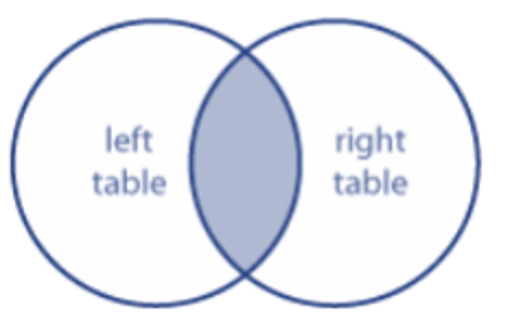

Keeps only rows of observations that have matching keys in x and y.

Example: Merge on the `new_emp1` data their performance rating.

```r
inner_join(new_emp1, performance, by = c("emp_id" = "id"))
```

| emp_id | name | sex | age | rating |
| --- | --- | --- | --- | --- |
| emp1291 | Jerry | M | 24 | 9 |
| emp4118 | Ben | M | 26 | 8 |
| emp2192 | Ria | F | 22 | 8 |
| emp1120 | Kyla | F | 25 | 8 |
| emp3192 | Trish | F | 30 | 10 |

### Left Outer Join

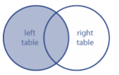

Keeps all rows in x (left table), and drops rows in y that has no key match

Example: Merge on the `new_emp1` data their performance rating, but keep those even who are not in the `performance` table.

```r
left_join(new_emp1, performance, by = c("emp_id" = "id"))
```

| emp_id | name | sex | age | rating |
| --- | --- | --- | --- | --- |
| emp2011 | John | M | 23 | NA |
| emp1291 | Jerry | M | 24 | 9 |
| emp4118 | Ben | M | 26 | 8 |
| emp1003 | Ken | M | 24 | NA |
| emp2192 | Ria | F | 22 | 8 |
| emp1120 | Kyla | F | 25 | 8 |
| emp3192 | Trish | F | 30 | 10 |

You will see that emp2011 and emp1003 are retained in the output even if they have no performance rating.

### Right Outer Join

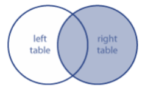

Keeps all rows in y (right table), and drops rows in x that has no key match

Example: In the `performance` table, there are some employees that are not in the `new_emp1` table. Show all ratings of all employees with available rating, even if they don’t have employee details.

```r
right_join(new_emp1, performance, by = c("emp_id" = "id"))
```

| emp_id | name | sex | age | rating |
| --- | --- | --- | --- | --- |
| emp1291 | Jerry | M | 24 | 9 |
| emp4118 | Ben | M | 26 | 8 |
| emp2192 | Ria | F | 22 | 8 |
| emp1120 | Kyla | F | 25 | 8 |
| emp3192 | Trish | F | 30 | 10 |
| emp1027 | NA | NA | NA | 7 |
| emp2190 | NA | NA | NA | 8 |
| emp4815 | NA | NA | NA | 8 |

### Full Outer join

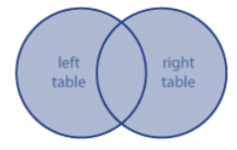

Keeps all rows in x and y.

Example: Show all employee details and rating

```r
new_emp1 %>%
  select(emp_id, name) %>%
  distinct() %>%
  full_join(performance, by = c("emp_id" = "id"))
```

| emp_id | name | rating |
| --- | --- | --- |
| emp2011 | John | NA |
| emp1291 | Jerry | 9 |
| emp4118 | Ben | 8 |
| emp1003 | Ken | NA |
| emp2192 | Ria | 8 |
| emp1120 | Kyla | 8 |
| emp3192 | Trish | 10 |
| emp1027 | NA | 7 |
| emp2190 | NA | 8 |
| emp4815 | NA | 8 |

## Filtering Joins

The “filtering joins” **filter rows from `x`** based on the **presence or absence of matches in `y`**. Filtering joins **keeps all columns on `x`**, but unlike the mutating joins, this **drops columns in `y`** other than the key column (specified by the `by` parameter)

### Semi-join

Keeps all observations in x (left table) that have a match in y (right table).

Example: get rows from `new_emp1` that have rating, which is stored in `performance`.

```r
semi_join(new_emp1, performance, by = c("emp_id" = "id"))
```

| emp_id | name | sex | age |
| --- | --- | --- | --- |
| emp1291 | Jerry | M | 24 |
| emp4118 | Ben | M | 26 |
| emp2192 | Ria | F | 22 |
| emp1120 | Kyla | F | 25 |
| emp3192 | Trish | F | 30 |

Note that unlike inner join, the `rating` column is note appended.

### Anti-join

Returns all rows from `x` that has no match in `y`.

Example: Find employees that have no performance rating

```r
anti_join(new_emp1, performance, by = c("emp_id" = "id"))
```

| emp_id | name | sex | age |
| --- | --- | --- | --- |
| emp2011 | John | M | 23 |
| emp1003 | Ken | M | 24 |

## Set Operations

For the set operations, they expect that the **two tables have same columns** and they treat **each row as a set element.** Unlike the join functions, these do not require a key column; all columns are key columns.

For the following examples, let’s recall first the contents of the two tables `new_emp1` and `new_emp2` which both have 7 rows and 4 columns: `emp_id`, `name`, `sex`, and `age`

```r
new_emp1
```

| emp_id | name | sex | age |
| --- | --- | --- | --- |
| emp2011 | John | M | 23 |
| emp1291 | Jerry | M | 24 |
| emp4118 | Ben | M | 26 |
| emp1003 | Ken | M | 24 |
| emp2192 | Ria | F | 22 |
| emp1120 | Kyla | F | 25 |
| emp3192 | Trish | F | 30 |

```r
new_emp2
```

| emp_id | name | sex | age |
| --- | --- | --- | --- |
| emp1291 | Jerry | M | 24 |
| emp4118 | Ben | M | 26 |
| emp2192 | Ria | F | 22 |
| emp1027 | Nelson | M | 28 |
| emp2190 | EJ | F | 23 |
| emp4815 | Sarah | F | 27 |
| emp3753 | Anton | M | 25 |

### Intersection

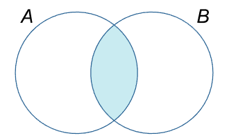

Returns observations present in both tables, and removes duplicates.

```r
intersect(new_emp1, new_emp2)
```

| emp_id | name | sex | age |
| --- | --- | --- | --- |
| emp1291 | Jerry | M | 24 |
| emp4118 | Ben | M | 26 |
| emp2192 | Ria | F | 22 |

The three observations are both present in `new_emp1` and `new_emp2`.

### Union

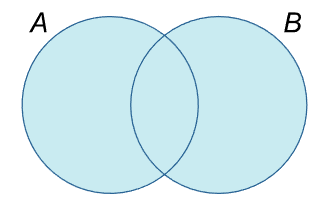

Returns all unique observations in both tables

```r
dplyr::union(new_emp1, new_emp2)
```

| emp_id | name | sex | age |
| --- | --- | --- | --- |
| emp2011 | John | M | 23 |
| emp1291 | Jerry | M | 24 |
| emp4118 | Ben | M | 26 |
| emp1003 | Ken | M | 24 |
| emp2192 | Ria | F | 22 |
| emp1120 | Kyla | F | 25 |
| emp3192 | Trish | F | 30 |
| emp1027 | Nelson | M | 28 |
| emp2190 | EJ | F | 23 |
| emp4815 | Sarah | F | 27 |

[output cut: 1 more lines]

Note that 3 employees, `emp1291`, `emp4118`, `emp2192` are present in both tables, but only one of each are returned.

### Union All

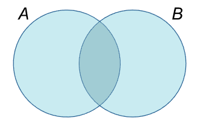

Takes the union without dropping the duplicates.

```r
dplyr::union_all(new_emp1, new_emp2)
```

| emp_id | name | sex | age |
| --- | --- | --- | --- |
| emp2011 | John | M | 23 |
| emp1291 | Jerry | M | 24 |
| emp4118 | Ben | M | 26 |
| emp1003 | Ken | M | 24 |
| emp2192 | Ria | F | 22 |
| emp1120 | Kyla | F | 25 |
| emp3192 | Trish | F | 30 |
| emp1291 | Jerry | M | 24 |
| emp4118 | Ben | M | 26 |
| emp2192 | Ria | F | 22 |

[output cut: 4 more lines]

Notice that all 7 rows from `new_emp1` and 7 rows from `new_emp2` are retained. Also, result is the same with the `rbind` and `bind_rows` functions.

```r
rbind(new_emp1, new_emp2)
```

| emp_id | name | sex | age |
| --- | --- | --- | --- |
| emp2011 | John | M | 23 |
| emp1291 | Jerry | M | 24 |
| emp4118 | Ben | M | 26 |
| emp1003 | Ken | M | 24 |
| emp2192 | Ria | F | 22 |
| emp1120 | Kyla | F | 25 |
| emp3192 | Trish | F | 30 |
| emp1291 | Jerry | M | 24 |
| emp4118 | Ben | M | 26 |
| emp2192 | Ria | F | 22 |

[output cut: 4 more lines]

```r
bind_rows(new_emp1, new_emp2)
```

| emp_id | name | sex | age |
| --- | --- | --- | --- |
| emp2011 | John | M | 23 |
| emp1291 | Jerry | M | 24 |
| emp4118 | Ben | M | 26 |
| emp1003 | Ken | M | 24 |
| emp2192 | Ria | F | 22 |
| emp1120 | Kyla | F | 25 |
| emp3192 | Trish | F | 30 |
| emp1291 | Jerry | M | 24 |
| emp4118 | Ben | M | 26 |
| emp2192 | Ria | F | 22 |

[output cut: 4 more lines]

### Set Difference

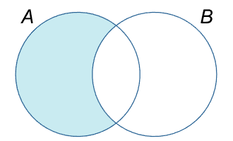

What’s in `new_emp1` that is not found in `new_emp2`?

```r
setdiff(new_emp1, new_emp2)
```

| emp_id | name | sex | age |
| --- | --- | --- | --- |
| emp2011 | John | M | 23 |
| emp1003 | Ken | M | 24 |
| emp1120 | Kyla | F | 25 |
| emp3192 | Trish | F | 30 |

```r
#new_emp1 except/minus new_emp2
```